# STAT 6502 HW #4

Daniel Park

March 2, 2016

### 11.1, 11.2, 11.3, 11.8, 11.15, 11.16, 11.19, 11.32, 11.34, 11.39

### 11.1

A computer was used to generate four random numbers from a normal distribution with a set mean and variance: $1.1650, 0.6268, 0.0751, 0.3516$. Five more random normal numbers with the same variance but perhaps a different mean were then generated (the mean may or may not actually be different): $0.3035, 2.6961, 1.0591, 2.7971, 1.2641$.

1. What do you think the means of the random normal number generators were? What do you think the difference of the means was?  
   **Solution**  
   Relying on the MLE for the mean of sample observations from a normal distribution, the means and differences are $\begin{aligned} \hat{\mu}_X &= \overline{X} = \frac{1}{4}(1.1650 + 0.6268 + 0.0751 + 0.3516) = 0.554625 \\ \hat{\mu}_Y &= \overline{Y} = \frac{1}{5}(0.3035 + 2.6961 + 1.0591 + 2.7971 + 1.2641) = 1.62398 \\ \hat{\mu}_X - \hat{\mu}_Y &= \overline{X} - \overline{Y} = 0.554625 - 1.62398 = -1.069355 \end{aligned}$
2. What do you think the variance of the random number generator was?  
   **Solution**  
   The variances, which are the same for the two sets, must be estimated by calculating the pooled sample variance, $s^2_p = \frac{(n-1)s_X^2 + (m-1)s_Y^2}{m+n-2}$ where $s^2_X = \frac{1}{n-1} \sum_{i=1}^n (X_i - \overline{X})^2$. Then we have $\begin{aligned} s^2_X = \frac{1}{3}\Big[&(1.1650-0.5546)^2 + (0.6268 - 0.5546)^2 + (0.0751 - 0.5546)^2 + (0.3516-0.5546)^2\Big] = 0.2163101 \\ s^2_Y = \frac{1}{4}\Big[&(0.3035-1.6240)^2 + (2.6961 - 1.6240)^2 + (1.0591 - 1.6240)^2 + (2.7971-1.6240)^2 + \\ &(1.2641-1.6240)^2\Big] = 1.1794806 \end{aligned}$ and then $s^2_p = \frac{(3)0.2163101 + (4)1.1794806}{7} = 0.7666932$
3. What is the estimated standard error of your estimate of the difference of the means?  
   **Solution**  
   Estimated standard error of $\overline{X} - \overline{Y}$: $\begin{aligned} s_{\overline{X}-\overline{Y}} &=s_p\sqrt{\frac{1}{n}+\frac{1}{m}} \\ &= 0.8756102 \sqrt{\frac{1}{4} + \frac{1}{5}} \\ &= 0.5873772 \end{aligned}$
4. Form a 90% confidence interval for the difference of the means of the random number generators.  
   **Solution**  
   A $100(1 - \alpha)\%$ confidence interval for $\mu_X - \mu_Y$ is $(\overline{X} - \overline{Y}) \pm t_{m+n-2, \ \alpha/2}s_{(\overline{X}-\overline{Y})}$ where $t_{(m+n-2,\alpha/2)}$=`qt(p=0.95, df=7)`=1.8945786. $-1.069355 \pm 1.8945786\cdot 0.5873772 \ \ \ \Longrightarrow \ \ \ -2.1821872 \geq \mu_X - \mu_Y \geq 0.0434772$
5. In this situation, is it more appropriate to use a one-sided test or a two-sided test of the equality of the means?  
   **Solution**  
   We should use a two-sided test. We are not told how the two sets of observations differ from each other. If we knew if one sample was either equal to or greater than a sample, then a one-sided test would be more appropriate.
6. What is the *p*-value of a two-sided test of the null hypothesis of equal means?  
   **Solution**  
   The test statistic is $\begin{aligned} t &= \frac{\overline{X} - \overline{Y}}{s_{(\overline{X} - \overline{Y})}} \\ &= \frac{-1.069355}{0.5873772} \\ &= -1.8205593 \end{aligned}$ The *p*-value is `2*pt(q=test.stat, df=n+m-2)`=0.1114772.  
   Or we may use `t.test()` function: `t.test(x=x, y=y, var.equal=TRUE)$p.value`: 0.1114772.
7. Would the hypothesis that the means were the same versus a two-sided alternative be rejected at the significance level $\alpha=0.1$?  
   **Solution**  
   The *p*-value indicates that the test statistic falls within the acceptance region if the significance level were $\alpha=0.1$. So the null hypothesis is not rejected.
8. Suppose you know that the variance of the normal distribution was $\sigma^2=1$. How would your answers to the preceding questions change?  
   **Solution**  
   The *t*-distribution is used when the population variance is unknown. When it is known, we may use the normal distribution.
   1. The means and their difference would be the same.
   2. The variance of the random generator is given: $\sigma^2=1$.
   3. When variance is known we know that $\overline{X} - \overline{Y} \sim N\bigg[\mu_X - \mu_Y, \sigma^2\bigg(\frac{1}{n} + \frac{1}{m}\bigg)\bigg]$ So the standard deviation is is $1\sqrt{\frac{1}{4} + \frac{1}{5}} = 0.6708204$
   4. The confidence interval is $(\overline{X} - \overline{Y}) \pm z_{(\alpha/2)}\sigma\sqrt{\frac{1}{n} + \frac{1}{m}} = -2.1727564, 0.0340464$
   5. Again, a two-sided test is more appropriate.
   6. The Z value is $Z=\frac{(\overline{X} - \overline{Y}) - (\mu_X - \mu_Y)}{\sigma^2\sqrt{\frac{1}{n} + \frac{1}{m}}} = -1.5941003$ The *p*-value is 0.1109136.
   7. Our test statistic falls in the acceptance region. Again, we fail to reject.

### 11.2

The difference of the means of two normal distrbutions with equal variance is to be estimated by sampling an equal number of observations from each distribution. If it were possible, would it be better to halve the standard deviations of the populations or double the sample sizes?

**Solution**  
Assuming that the variance is unknown (though equal), our test statistic is dependent on estimated standard error: $t = \frac{\overline{X} - \overline{Y}}{s_{(\overline{X} - \overline{Y})}}$ where $s_{(\overline{X} - \overline{Y})}=s_p\sqrt{\frac{1}{n} + \frac{1}{m}}= s_p\sqrt{\frac{2}{n}}$ A smaller pooled standard error would be beneficial since it would magnify the value of the *t*-statistic.

Comparing the halving of the standard error vs. doubling the sample sizes, $\begin{aligned} \bigg(\frac{1}{2}s_p\bigg)\sqrt{\frac{2}{n}} \ \ \ &? \ \ \ s_p\sqrt{\frac{2}{(2n)}} \\ s_p\sqrt{\frac{2}{4n}} \ \ \ &? \ \ \ s_p\sqrt{\frac{1}{n}} \\ s_p\sqrt{\frac{1}{2n}} \ \ \ &< \ \ \ s_p\sqrt{\frac{1}{n}} \end{aligned}$ So it is better to halve the standard error.

### 11.3

In Section 11.2.1, we considered two methods of estimating Var$(\overline{X} - \overline{Y})$. Under the assumption that the two population variances were equal, we estimated this quantity by $s^2_p\bigg(\frac{1}{n} + \frac{1}{m}\bigg)$ and without this assumption by $\frac{s_X^2}{n} + \frac{s_Y^2}{m}$ Show that these two estimates are identical if $m=n$.  
**Solution**  
The pooled variance is $s^2_p = \frac{(n-1)s_X^2 + (m-1)s_Y^2}{m+n-2}$ Substituting $s^2_p$ into the first equation and letting $\ell=m=n$, we have $\begin{aligned} s^2_p\bigg(\frac{1}{n} + \frac{1}{m}\bigg) &= \frac{(n-1)s_X^2 + (m-1)s_Y^2}{m+n-2} \bigg(\frac{1}{n} + \frac{1}{m}\bigg) \\ &= \frac{(\ell-1)s_X^2 + (\ell-1)s_Y^2}{\ell+\ell-2} \bigg(\frac{1}{\ell} + \frac{1}{\ell}\bigg) \\ &= \frac{(\ell-1)s_X^2 + (\ell-1)s_Y^2}{2(\ell-1)} \bigg(\frac{2}{\ell}\bigg) \\ &= \frac{s_X^2}{\ell} + \frac{s_Y^2}{\ell} \\ &= \frac{s_X^2}{n} + \frac{s_Y^2}{m} \end{aligned}$

### 11.8

An experiment to determine the efficacy of a drug for reducing high blood pressure is performed using four subjects in the following way: two of the subjects are chosen at random for the control group and two for the treatment group. During the course of treatment with the drug, the blood pressure of each of the subjects in the treatment group is measured for ten consecutive days as is the blood pressure of each of the subjects in the control group.

1. In order to test whether the treatment has an effect, do you think it is appropriate to use the two-sample *t* test with $n=m=20$?  
   **Solution**  
   No. If $n=m=20$ each sample represents an observation for one patient on one specific day. When the observations concern a single person, the samples are not independent An observation on one day would likely be correlated for a different day (for the same patient). Therefore, a two sample *t* test would not be appropriate.
2. Do you think it is appropriate to use the Mann-Whitney test with $n=m=20$?  
   **Solution**  
   No. The Mann-Whitney test involves creating ranks, and it is compared to a distribution where any permutation is equally likely. This is not the case here. The observations are not independent.

### 11.15

Suppose that $n$ measurements are to be taken under a treatment condition and another $n$ measurements are to be taken independently under a control condition. It is thought that the standard deviation of a single observation is about 10 under both conditions. How large should $n$ be so that a $95\%$ confidence interval for $\mu_X-\mu_Y$ has a width of $2$? Use the normal distribution rather than the $t$ distribution, since $n$ will turn out to be rather large.  
**Solution**  
Under a normal distribution, the confidence interval is $(\overline{X} - \overline{Y}) \pm z_{(\alpha /2)}\sigma \sqrt{\frac{1}{n} + \frac{1}{m}}$ In this case, $n=m$. To calculate the sample size to ensure a width of 2, we may utilize the normal distribution’s symmetry to simplify the derivation: $\begin{aligned} 1 &= z_{(\alpha /2)}\sigma \sqrt{\frac{1}{n} + \frac{1}{m}} \\ \frac{1}{z_{(\alpha /2)}\sigma} &= \sqrt{\frac{2}{n}} \\ \bigg(\frac{1}{z_{(\alpha /2)}\sigma}\bigg)^2 &= \frac{2}{n} \\ 2\big(z_{(\alpha /2)}\sigma\big)^2 &= n \\ \end{aligned}$ Given our values, we can plug them in $\begin{aligned} n &= 2\big(z_{(0.975)}\sigma\big)^2 \\ &= 2\big(1.96 \cdot 10\big)^2 \\ &= 768.32 \end{aligned}$ To ensure a 95% confidence interval with a width of 2, the sample size should be $769$.

### 11.16

Referring to Problem 15, how large should be $n$ be so that the test of $H_0: \mu_X=\mu_Y$ against the one-sided alternative $H_A:\mu_x > \mu_Y$ has a power of $0.5$ if $\mu_X-\mu_Y=2$ and $\alpha =0.10$?

**Solution**  
The rejection region for a one-sided test is $\overline{X} - \overline{Y} > z_{(\alpha)} \sigma \sqrt{\frac{2}{n}}$ The power is the probability that the test statistic falls in the rejection region: $\text{Power} = P\bigg[\overline{X} - \overline{Y} > z_{(\alpha)} \sigma \sqrt{\frac{2}{n}}\bigg]$ We know that $\overline{X} - \overline{Y} \sim N\bigg[\mu_Y - \mu_X, \sigma^2 \frac{2}{n}\bigg]$ Our goal is to manipulate the probability so that it follows a standard normal distribution $\begin{aligned} \overline{X} - \overline{Y} &> z_{(\alpha)} \sigma \sqrt{\frac{2}{n}} \\ (\overline{X} - \overline{Y}) - (\mu_X - \mu_Y) &> z_{(\alpha)} \sigma \sqrt{\frac{2}{n}} - (\mu_X - \mu_Y) \\ \frac{(\overline{X} - \overline{Y}) - (\mu_X - \mu_Y)}{\sigma\sqrt{2/n}} &> \frac{z_{(\alpha)} \sigma \sqrt{2/n} - (\mu_X - \mu_Y)}{\sigma \sqrt{2/n}} \\ Z &> \frac{z_{(\alpha)} \sigma \sqrt{2/n}}{\sigma \sqrt{2/n}} - \frac{(\mu_X - \mu_Y)}{\sigma \sqrt{2/n}} \\ Z &> z_{(\alpha)} - \frac{(\mu_X - \mu_Y)}{\sigma \sqrt{2/n}} \\ \end{aligned}$ So returning back to the probability $\begin{aligned} \text{Power} &= P\bigg[\overline{X} - \overline{Y} > z_{(\alpha)} \sigma \sqrt{\frac{2}{n}}\bigg] \\ &= P\bigg[Z > z_{(\alpha)} - \frac{(\mu_X - \mu_Y)}{\sigma \sqrt{2/n}}\bigg] \\ &= 1 - \Phi\bigg[z_{(\alpha)} - \frac{(\mu_X - \mu_Y)}{\sigma \sqrt{2/n}}\bigg] \end{aligned}$ Plug in our known values $\begin{aligned} 0.5 &= 1 - \Phi\bigg[z_{(0.10)} - \frac{2}{10 \sqrt{2/n}}\bigg] \\ \Phi\bigg[1.28 - \frac{1}{5 \sqrt{2/n}}\bigg] &= 0.5 \end{aligned}$ Since 0.5 is the median we know that $\Phi(0)=0.5$. So $\begin{aligned} 0 &= 1.28 - \frac{1}{5 \sqrt{2/n}} \\ n &= 81.92 \end{aligned}$ So $n$ should be at least $82$.

### 11.19

An experiment is planned to compare the mean of a control group to the mean of an independent sample of a group given a treatment. Suppose that there are to be 25 samples in each group. Suppose that the observations are approximately normally distributed and that the standard deviation of a single measurement in either group is $\sigma = 5$.

1. What will the standard error of $\overline{Y}-\overline{X}$ be?  
   **Solution**  
   Given our scenario of two sets of samples from normally distributed populations with known and equal variance, $\overline{Y} - \overline{X} \sim N\bigg[\mu_Y - \mu_X, \sigma^2 \bigg(\frac{1}{n} + \frac{1}{m}\bigg)\bigg]$ So the standard error is $\begin{aligned} \sqrt{\sigma^2\bigg(\frac{1}{n} + \frac{1}{m}\bigg)} &= 5\sqrt{\frac{1}{25} + \frac{1}{25}} \\ &= \sqrt{2} \end{aligned}$
2. With a significance level $\alpha=0.05$, what is the rejection region of the test of the null hypothesis $H_0: \mu_Y = \mu_X$ versus the alternative $H_A: \mu_Y > \mu_X$?  
   **Solution**  
   The rejection region would be $\begin{aligned} \overline{Y} - \overline{X} &> z_{(\alpha)}\sigma \sqrt{\frac{1}{n} + \frac{1}{m}} \\ &> 1.64 \cdot 5 \sqrt{\frac{2}{25}} \\ &> 2.33 \end{aligned}$
3. What is the power of the test if $\mu_Y = \mu_X + 1?$  
   **Solution**  
   Under $H_1$, $\overline{Y} - \overline{X} \sim N\bigg[\mu_Y - \mu_X, \sigma^2 \bigg(\frac{1}{n} + \frac{1}{m}\bigg)\bigg] = N(1, 2)$

```r
1 - pnorm(q=2.33 , mean=1, sd=sqrt(2))
```

```
## [1] 0.1734929
```

4. Suppose that the *p*-value of the test turns out to be $0.07$. Would the test reject at significance level $\alpha=0.10$?  
   **Solution**  
   If we are performing a one-sided test as in (b), then we would reject the null hypothesis with a *p*-value of $0.07$. The *p*-value is less than $\alpha$.
5. What is the rejection region if the alternative is $H_A:\mu_Y \neq \mu_X$? What is the power if $\mu_Y=\mu_X + 1$?  
   **Solution**  
   The rejection in this scenario is $\begin{aligned} \Big| \overline{Y} - \overline{X} \Big| &> z_{(\alpha /2)}\sigma \sqrt{\frac{1}{n} + \frac{1}{m}} \\ &> z_{(0.05/2)}5 \sqrt{\frac{1}{25} + \frac{1}{25}} \\ &> 1.96 \sqrt{2} \\ &> 2.77 \end{aligned}$ Power:

```r
1 - pnorm(q=2.77 , mean=1, sd=sqrt(2)) + pnorm(q=-2.77 , mean=1, sd=sqrt(2))
```

```
## [1] 0.109202
```

### 11.32

If $X \sim N(\mu_X, \sigma_X^2)$ and $Y$ is independent $N(\mu_Y, \sigma_Y^2)$, what is $\pi=P(X<Y)$ in terms of $\mu_X, \mu_Y, \sigma_X,$ and $\sigma_Y$?  
**Solution**  
We know that the sum/difference of random variables from a normal distribution also follow a normal distribution. In this case $Y-X \sim N(Y-X, \sigma^2_Y + \sigma^2_X)$ Then converting $Y-X$ into a standard normal distribution: $\frac{(Y-X) - (\mu_Y - \mu_X)}{\sqrt{\sigma^2_Y + \sigma^2_X}} \sim N(0,1)$ So then we have: $\begin{aligned} P(X<Y) &= P(Y-X > 0) \\ &= P[(Y-X) - (\mu_Y - \mu_X) > 0 - (\mu_Y - \mu_X)] \\ &= P\bigg(\frac{(Y-X) - (\mu_Y - \mu_X)}{\sqrt{\sigma^2_Y + \sigma^2_X}} > \frac{ - (\mu_Y - \mu_X)}{\sqrt{\sigma^2_Y + \sigma^2_X}}\bigg) \\ &= P\bigg(Z > \frac{ - (\mu_Y - \mu_X)}{\sqrt{\sigma^2_Y + \sigma^2_X}}\bigg) \\ &= 1 - \Phi\bigg(\frac{ - (\mu_Y - \mu_X)}{\sqrt{\sigma^2_Y + \sigma^2_X}}\bigg) \end{aligned}$

### 11.34

This problem contrasts the power functions of paired and unpaired designs. Graph and compare the power curves for testing $H_0: \mu_X=\mu_Y$ for the following two designs.

1. Paired: Cov$(X_i, Y_i)=50, \sigma_X=\sigma_Y=10, i=1, \dots, 25$.  
   **Solution**  
   $\rho = \frac{\sigma_{XY}}{\sigma_X \sigma_Y}=\frac{50}{10 \cdot 10}$  
   $\text{Var}(\overline{D}) = \frac{1}{n}(\sigma^2_X + \sigma^2_Y - 2 \rho \sigma_X\sigma_Y)=\frac{1}{25}(100 + 100 - 2 \cdot 0.5 \cdot 10 \cdot 10) = 4$

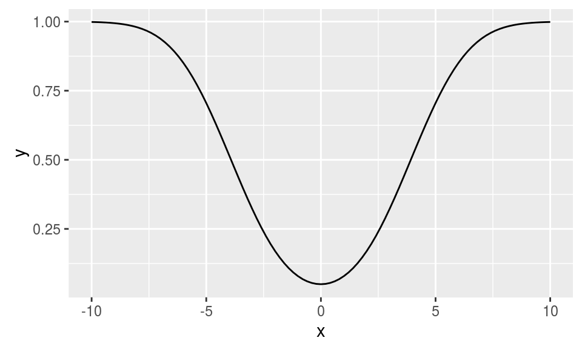

```r
library(ggplot2)
ggplot(data.frame(x=c(-10, 10)), aes(x)) +
  stat_function(fun=function(x) pnorm(q=-1.96*2, mean=x, sd=2) +
                  1-pnorm(q=1.96*2, mean=x, sd=2))
```

2. Unpaired: $X_1, \dots, X_{25}$ and $Y_1, \dots, Y_{25}$ are independent with variance as in part (a).  
   **Solution**  
   If $X$ and $Y$ are independent, then $\sigma_{XY}=\rho=0$. So  
   $\text{Var}(\overline{D}) = \frac{1}{n}(\sigma^2_X + \sigma^2_Y - 2 \rho \sigma_X\sigma_Y)=\frac{1}{25}(100 + 100 - 2 \cdot 0 \cdot 10 \cdot 10) = 8$

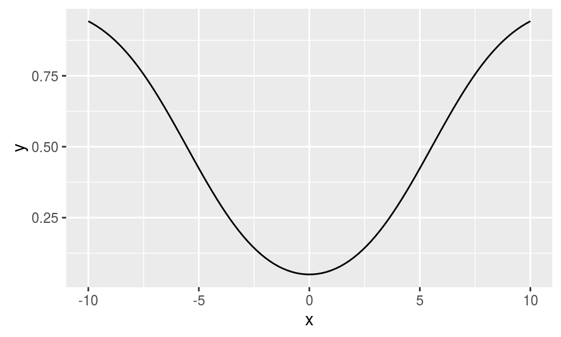

```r
ggplot(data.frame(x=c(-10, 10)), aes(x)) +
  stat_function(fun=function(x) pnorm(q=-1.96*sqrt(8), mean=x, sd=sqrt(8)) + 1-pnorm(q=1.96*sqrt(8), mean=x, sd=sqrt(8)))
```

### 11.39

An experiment was done to test a method for reducing faults on telephone lines (Welch 1987). Fourteen matched pairs of areas were used. The following table show the fault rates for the control areas and for the test areas:

| Test | Control |
| --- | --- |
| 676 | 88 |
| 206 | 570 |
| 230 | 605 |
| 256 | 617 |
| 280 | 653 |
| 433 | 2913 |
| 337 | 924 |
| 466 | 286 |
| 497 | 1098 |
| 512 | 982 |
| 794 | 2346 |
| 428 | 321 |
| 452 | 615 |
| 512 | 519 |

1. Plot the differences versus the control rate and summarize what you see.

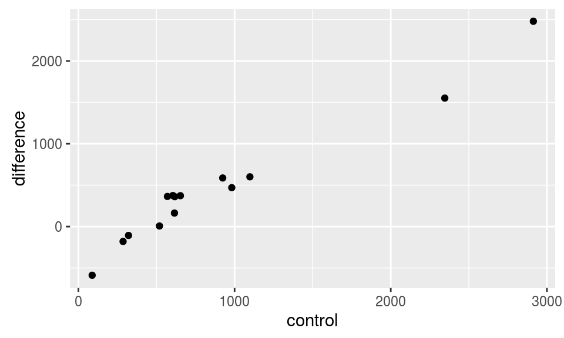

```r
library(ggplot2)
qplot(x=control, y=difference, data=phone)
```

There is a strong correlation between the difference and the control.

2. Calculate the mean difference, its standard deviation, and a confidence interval.

Mean difference:

```r
control.bar <- mean(phone$control)
test.bar <- mean(phone$test)
(mean.diff <- control.bar - test.bar)
```

```
## [1] 461.2857
```

Standard deviation:

```r
# Answers are the same
#(sd.dbar <- sqrt(var(phone$control)/14 + var(phone$test)/14 - cov(phone$control, phone$test)*2/14))
(sd.dbar <- sqrt(var(phone$difference)/nrow(phone)))
```

```
## [1] 202.533
```

95% Confidence interval: $\overline{D} \pm t_{(n-1, \alpha/2)}s_{\overline{D}}$

```r
mean.diff + c(qt(p=0.025, df=14-1), qt(p=0.975, df=14-1))*sd.dbar
```

```
## [1]  23.73969 898.83174
```

```r
wilcox.test(x=phone$control, y=phone$test,  paired=TRUE)
```

```
##
##  Wilcoxon signed rank test
##
## data:  phone$control and phone$test
## V = 88, p-value = 0.02454
## alternative hypothesis: true location shift is not equal to 0
```

```r
t.test(x=phone$control, y=phone$test,  paired=TRUE, var.equal=TRUE)
```

```
##
##  Paired t-test
##
## data:  phone$control and phone$test
## t = 2.2776, df = 13, p-value = 0.0403
## alternative hypothesis: true difference in means is not equal to 0
## 95 percent confidence interval:
##   23.73969 898.83174
## sample estimates:
## mean of the differences
##                461.2857
```